# Age at First Marriage in Bangladesh: An Analysis of Socio-Demographic Factors

Kuenley Zam

# Introduction

Early marriage remains a critical issue in many parts of the world, particularly in South Asia. Bangladesh, in particular, has historically exhibited high rates of early marriage among women. This report examines how the age at first marriage varies across different socio-demographic groups using data from the Bangladesh Demographic and Health Survey (BDHS) 2017–18. Our analysis focuses on three primary factors: educational attainment, place of residence (urban vs rural), and household wealth quintile.

## Data Source and Methods

The data used for this analysis comes from the 2017–18 BDHS Individual Recode (IR) file (`BDIR7RFL.DTA`), which contains responses from women aged 15–49. The variable of interest is `v511`, which represents the respondent’s age at first marriage. We cross-tabulated and visualized `v511` against education (`v106`), wealth quintile (`v190`), and place of residence (`v025`).

## Findings

### Education and Age at Marriage

We found a clear association between education and age at marriage. As shown below, the mean age at marriage increases with higher levels of education.

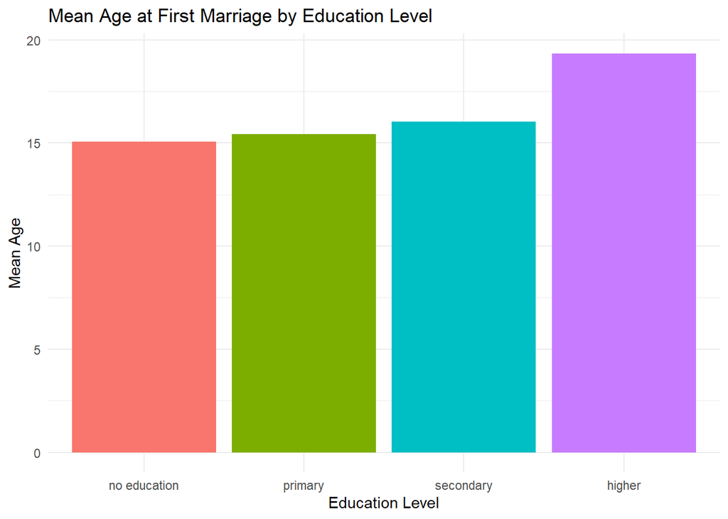

### Residence and Age at Marriage

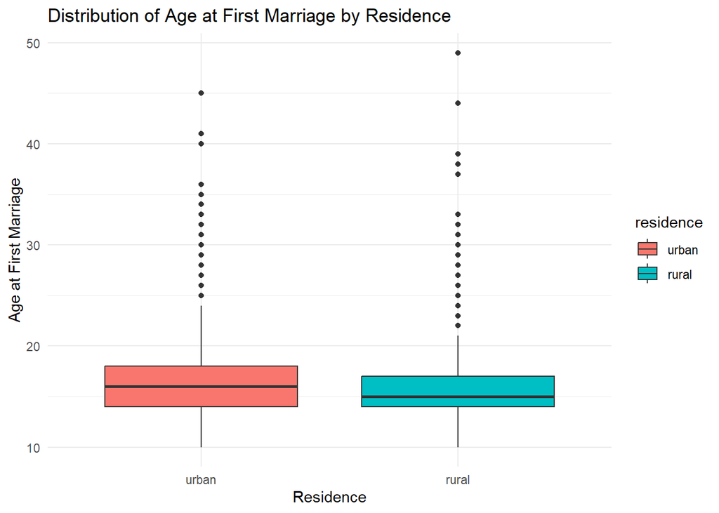

Women in urban settings tend to marry slightly later than those in rural areas. The interquartile range is also broader in urban areas, suggesting more variability and possibly greater autonomy in marital decisions.

### Wealth and Age at Marriage

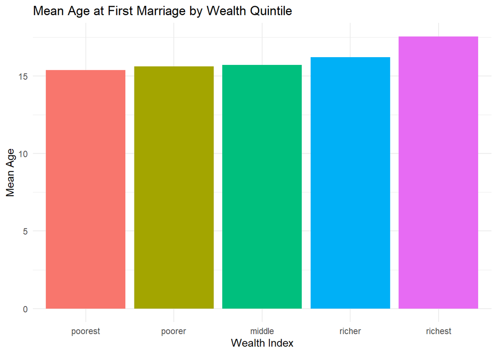

Women from the richest quintile marry, on average, about 2 years later than those from the poorest quintile. This trend may reflect increased educational opportunities and empowerment linked to wealth.

### Distribution of Marriage Age by Education

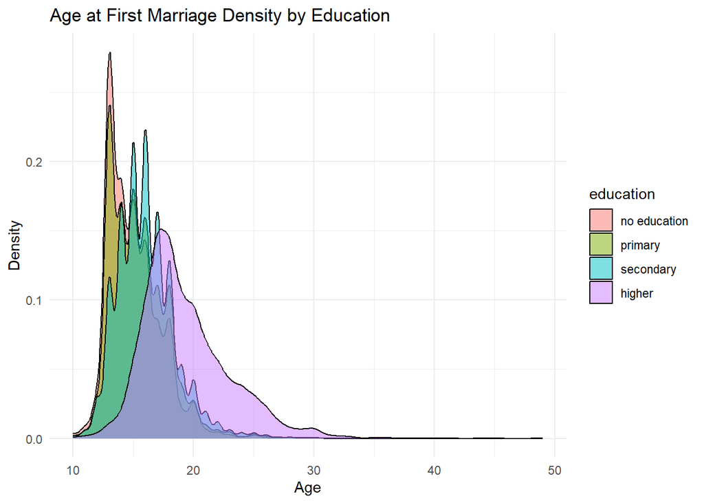

### Summary Table

Age at First Marriage Summary by Education Level

| highest educational level | Mean_Age | Min_Age | Max_Age | Count |
| --- | --- | --- | --- | --- |
| no education | 15.1 | 10 | 49 | 3202 |
| primary | 15.4 | 10 | 44 | 6340 |
| secondary | 16.0 | 10 | 45 | 7764 |
| higher | 19.3 | 10 | 36 | 2821 |

This table clearly illustrates the differences in marriage age by education level and reinforces the trends observed in our visualizations.